# 🎶 Hit Song Predictor: Amapiano & Afrobeats 🎧

This project explores whether a song's audio features and metadata can predict its hit potential. We focus on Amapiano and Afrobeats, genres currently dominating African and global music scenes.

```python
from IPython.display import display, HTML
display(HTML("<p><em> Press play to start the mix if your browser blocked autoplay.</em></p>"))

#Playlist intro
display(HTML("""
<h3>🎧 Now Playing: Amapiano & Afrobeats Mix</h3>
<p><strong>Tracklist:</strong><br>
1. Jealousy – Khalil Harrison (Amapiano)<br>
2. Shake Ah – Tyla (Amapiano)<br>
3. Woman – Rema (Afrobeats)<br>
4. Zenzele – Uncle Waffles (Amapiano)<br>
5. No Competition – Davido ft. Asake (Afrobeats)<br>
6. Bunda – Musa Keys (Amapiano)<br>
7. Laho – Shalipopi (Afrobeats)<br>
8. My Darling – Chella (Afrobeats)
</p>
"""))

#Audio player (autoplay with user controls)
display(HTML("""
<audio autoplay controls>
  <source src="Afrobeats and Amapiano mix.mp3" type="audio/mpeg">
  Your browser does not support the audio element.
</audio>
"""))
```

*Press play to start the mix if your browser blocked autoplay.*

🎧 Now Playing: Amapiano & Afrobeats Mix

**Tracklist:**  
1. Jealousy – Khalil Harrison (Amapiano)  
2. Shake Ah – Tyla (Amapiano)  
3. Woman – Rema (Afrobeats)  
4. Zenzele – Uncle Waffles (Amapiano)  
5. No Competition – Davido ft. Asake (Afrobeats)  
6. Bunda – Musa Keys (Amapiano)  
7. Laho – Shalipopi (Afrobeats)  
8. My Darling – Chella (Afrobeats)

[interactive chart not shown]

## Purpose of Project

### Applying machine learning to music has proven insightful: computers can detect qualities of songs that resonate with audiences. Academic resemarch has shown that hit songs often share certain characteristics. For example, a study analyzing 30 years of music found “successful songs are happier, brighter, more party-like, more danceable and less sad than most songs” [(Kaplan, 2018)](https://www.latimes.com/science/sciencenow/la-sci-sn-pop-song-success-20180516-story.html#:~:text=Sure%20enough%2C%20some%20noteworthy%20patterns,emerged).In summary, building a hit song prediction model is important and appealing because it combines scientific rigor with cultural relevance. It helps company stakeholders make smarter decisions.

## 1. Import Libraries and Set Up

```python
#Import necessary libraries for Spotify API access, data handling, and file management
import spotipy
from spotipy.oauth2 import SpotifyOAuth
import pandas as pd
import time
import os

#Create a directory called "data" to save all downloaded or processed datasets
#This keeps the project organized and avoids cluttering the main directory
os.makedirs("data", exist_ok=True)
```

## 2. Spotify API Authentication

```python
#Authenticate with Spotify's API using OAuth 2.0 flow
#This gives access to user-specific data like saved tracks and private playlists
sp = spotipy.Spotify(auth_manager=SpotifyOAuth(
    client_id=os.environ["SPOTIPY_CLIENT_ID"],
    client_secret= os.environ["SPOTIPY_CLIENT_SECRET"],
    redirect_uri="http://127.0.0.1:8891/callback",
    scope="playlist-read-private playlist-read-collaborative"
))

#Test connection by pulling a few liked songs from Spotify account
#This confirms that access token works and successfully authenticatedresults = sp.current_user_saved_tracks(limit=5)
results = sp.current_user_saved_tracks(limit=5)
for item in results['items']:
    track = item['track']
    print(f"{track['name']} by {track['artists'][0]['name']}")
```

```
GIRLFRIEND by Tayc
For The Night by Tayo J
Petit génie by Jungeli
Focus On Me (All The Sexy Girls In The Club) by Darkoo
That Should Be Me by Justin Bieber
```

## 3. Extract Playlists Data from Spotify (looking for popularity score)

```python
#Define a dictionary of confirmed working playlists across Afrobeats and Amapiano genres
#Each playlist maps to its unique Spotify ID for reliable API access
working_playlists = {
    'Best of Afrobeats 2025': '5FDBAbJobJWaKh1RDiqtyn',
    'TikTok Naija': '1H4Ws8FYRXbUCFgpYAZdK3',
    'Afrobeats Party': '1U8HSDxH8lXHQ38epJngtG',
    'Afrobeat 2025': '7IfWkPjxjtGpHKzvbZd8YV',
    'Weekly Top Grooves': '4z8jM6c6NLp0H0szju3flc',
    'African Heat': '3Uj9Y8xviyC4BvC9R49reX',
    'Best of Amapiano': '1JtkyBr4Is4ni1UQAa9AVg',
    'AmaPiano March-April 2025': '74QpABGrU1VAdBlnaJqATL',
    'Amapiano New Finds': '7LQ1WmcPCKJtXT5uQl3waU',
    'playlist_id' : '5sFUBxyx9qpGDFOCPBEd82'


}


#Authenticate with the Spotify API using secure OAuth credentials
#Scope is limited to playlist access for data collection purposes
sp = spotipy.Spotify(auth_manager=SpotifyOAuth(
    client_id=os.environ["SPOTIPY_CLIENT_ID"],
    client_secret= os.environ["SPOTIPY_CLIENT_SECRET"],
    redirect_uri="http://127.0.0.1:8891/callback",
    scope="playlist-read-private playlist-read-collaborative"
))

#Initialize container to hold track-level data collected from all playlists
track_data = []

#Loop through each playlist, fetch up to 100 tracks at a time, and append relevant metadata
for playlist_name, playlist_id in working_playlists.items():
    try:
        print(f"Fetching from: {playlist_name}")
        offset = 0
        while True:
            results = sp.playlist_items(playlist_id, limit=100, offset=offset)
            if not results['items']:
                break

            for item in results['items']:
                track = item['track']
                if track:  # Make sure it's not None
                    track_data.append({
                        'playlist': playlist_name,
                        'track_name': track['name'],
                        'artist': track['artists'][0]['name'],
                        'track_id': track['id'],
                        'popularity': track['popularity']
                    })
            offset += 100
            time.sleep(0.5)  #To respect rate limits
    except Exception as e:
        print(f"Failed to fetch from {playlist_name}: {e}")

#Convert collected data to a structured DataFrame and export to CSV for further analysis
df_tracks = pd.DataFrame(track_data)
# df_tracks.to_csv("playlist_and_all_audio_done.csv", index=False)
```

```
Fetching from: Best of Afrobeats 2025
Fetching from: TikTok Naija
Fetching from: Afrobeats Party
Fetching from: Afrobeat 2025
Fetching from: Weekly Top Grooves
Fetching from: African Heat
Fetching from: Best of Amapiano
Fetching from: AmaPiano March-April 2025
Fetching from: Amapiano New Finds
Fetching from: playlist_id
```

## 4. Collect Spotify Stream Data for Recent Trending Afrobeats and Amampiano Songs (Will Measure Popularity by Streams Per Day Later)

```python
#Stream Data
#📊 Contains total stream counts, genre labels, and release dates for Afrobeats and Amapiano songs
#Data includes music from Nigeria (afrobeats top 30 current spotify songs) and South Africa (top 30 current spotify songs), reflecting regional and cultural relevance

stream_data = {
    # --- AFROBEATS songs ---
    "my darling": {"streams": 4_924_774, "genre": "Afrobeats", "release_date": "2025-03-27"},
    "arike": {"streams": 22_434_165, "genre": "Afrobeats", "release_date": "2025-02-15"},
    "are you there?": {"streams": 31_946_737, "genre": "Afrobeats", "release_date": "2024-08-16"},
    "awolowo": {"streams": 48_842_828, "genre": "Afrobeats", "release_date": "2024-08-14"},
    "beamer": {"streams": 11_580_503, "genre": "Afrobeats", "release_date": "2024-10-14"},
    "be there still": {"streams": 6_737_818, "genre": "Afrobeats", "release_date": "2025-02-14"},
    "chandelier": {"streams": 17_369_585, "genre": "Afrobeats", "release_date": "2024-11-21"},
    "na scra": {"streams": 7_248_693, "genre": "Afrobeats", "release_date": "2025-03-07"},
    "doha": {"streams": 27_380_251, "genre": "Afrobeats", "release_date": "2024-07-13"},
    "free of charge": {"streams": 1_915_678, "genre": "Afrobeats", "release_date": "2025-03-27"},
    "pity this boy (with victony)": {"streams": 21_224_424, "genre": "Afrobeats", "release_date": "2025-02-28"},
    "get better": {"streams": 4_857_075, "genre": "Afrobeats", "release_date": "2025-03-21"},
    "funds (feat. odumodublvck & chike)": {"streams": 42_455_477, "genre": "Afrobeats", "release_date": "2024-12-06"},
    "happy": {"streams": 8_112_951, "genre": "Afrobeats", "release_date": "2025-02-20"},
    "hey jago": {"streams": 2_993_456, "genre": "Afrobeats", "release_date": "2025-03-18"},
    "joy is coming": {"streams": 37_092_308, "genre": "Afrobeats", "release_date": "2024-12-18"},
    "JUJU (feat. Shallipopi)": {"streams": 41_465_826, "genre": "Afrobeats", "release_date": "2024-08-22"},
    "kese (dance)": {"streams": 45_694_575, "genre": "Afrobeats", "release_date": "2024-10-15"},
    "baby (is it a crime)": {"streams": 35_551_585, "genre": "Afrobeats", "release_date": "2025-02-07"},
    "shaolin": {"streams": 12_715_482, "genre": "Afrobeats", "release_date": "2025-02-10"},
    "management": {"streams": 6_204_585, "genre": "Afrobeats", "release_date": "2025-01-25"},
    "most wanted": {"streams": 1_837_793, "genre": "Afrobeats", "release_date": "2025-04-04"},
    "mario kart": {"streams": 8_687_810, "genre": "Afrobeats", "release_date": "2025-02-20"},
    "legolas": {"streams": 1_955_624, "genre": "Afrobeats", "release_date": "2025-03-31"},
    "trenches luv": {"streams": 4_312_356, "genre": "Afrobeats", "release_date": "2025-02-13"},
    "toy girl (with juno & valentino rose)": {"streams": 1_197_925, "genre": "Afrobeats", "release_date": "2025-03-31"},
    "venus": {"streams": 26_775_718, "genre": "Afrobeats", "release_date": "2025-02-21"},
    "why love": {"streams": 10_384_733, "genre": "Afrobeats", "release_date": "2025-02-12"},

    # --- AMAPIANO songs ---
    "Sdudla or Slender": {"streams": 2_894_712, "genre": "Amapiano", "release_date": "2025-03-20"},
    "Vuma Dlozi Lami (feat. Ancestral Rituals)": {"streams": 9_243_178, "genre": "Amapiano", "release_date": "2024-09-21"},
    "Ngisakuthanda": {"streams": 7_241_847, "genre": "Amapiano", "release_date": "2024-09-06"},
    "Ngibolekeni (feat. Seun1401, LeeMcKrazy, Blxckie, Pcee, Madumane & Kabelo Sings)": {"streams": 5_852_759, "genre": "Amapiano", "release_date": "2025-01-31"},
    "Vuka (feat. Thukuthela)": {"streams": 8_720_251, "genre": "Amapiano", "release_date": "2024-12-15"},
    "Uyaphapha Marn (feat. Scotts Maphuma & Kabelo Sings)": {"streams": 4_838_765, "genre": "Amapiano", "release_date": "2025-01-31"},
    "Wayengenalutho": {"streams": 4_610_909, "genre": "Amapiano", "release_date": "2025-02-21"},
    "Sohlala Sisonke": {"streams": 12_909_636, "genre": "Amapiano", "release_date": "2025-02-14"},
    "Bo Gogo (feat. Tracy & Thatohatsi)": {"streams": 6_078_812, "genre": "Amapiano", "release_date": "2025-01-31"},
    "HAUSAPIANO - Remix": {"streams": 21_129_492, "genre": "Amapiano", "release_date": "2024-10-31"},
    "Uvume Kanjani?": {"streams": 1_289_020, "genre": "Amapiano", "release_date": "2025-03-21"},
    "Biri Marung (feat. Sje Konka, Focalistic, DJ Maphorisa, Scotts Maphuma & CowBoii)": {"streams": 23_859_597, "genre": "Amapiano", "release_date": "2024-10-20"},
    "Romeo & Juliet": {"streams": 4_674_070, "genre": "Amapiano", "release_date": "2025-01-22"},
    "Shapa Bell": {"streams": 1_339_189, "genre": "Amapiano", "release_date": "2025-04-01"},
    "Abantwana Bakho (feat. Thatohatsi, Young Stunna & Nkosazana Daughter)": {"streams": 790_174, "genre": "Amapiano", "release_date": "2025-03-28"},
    "Malunde (feat. Springle)": {"streams": 864_570, "genre": "Amapiano", "release_date": "2024-12-13"},
    "Vulani (feat. Thatohatsi & Tracy)": {"streams": 3_295_409, "genre": "Amapiano", "release_date": "2024-12-09"},
    "Skuta Baba - Remix": {"streams": 7_294_010, "genre": "Amapiano", "release_date": "2024-12-06"},
    "Ungangilimazi (feat. Frank Mabeat)": {"streams": 4_937_736, "genre": "Amapiano", "release_date": "2024-09-20"},
    "All My Life": {"streams": 10_706_356, "genre": "Amapiano", "release_date": "2024-08-30"},
    "Awuhlabe Kabili": {"streams": 3_409_948, "genre": "Amapiano", "release_date": "2024-12-06"},
    "ZENZELE (feat. Royal MusiQ, Uncool MC, Xduppy, & CowBoii)": {"streams": 2_014_490, "genre": "Amapiano", "release_date": "2025-03-15"},
    "Naledi": {"streams": 1_401_369, "genre": "Amapiano", "release_date": "2025-03-10"},
    "UYAH! (feat. 2wo Bunnies, Jay Music, & Imbongi Yosizi)": {"streams": 2_223_683, "genre": "Amapiano", "release_date": "2025-02-10"},
    "Ngiyakuthanda": {"streams": 3_686_853, "genre": "Amapiano", "release_date": "2025-02-02"},
    "Shayi'Moto (feat. Seemah & Yanda Woods)": {"streams": 9_941_374, "genre": "Amapiano", "release_date": "2024-11-01"},
    "Wishi Wishi (feat. Scotts Maphuma & Young Stunna)": {"streams":13_211_203, "genre": "Amapiano", "release_date": "2024-09-29"},
    "Dear Ex Yami": {"streams": 5_231_036, "genre": "Amapiano", "release_date": "2024-09-22"},
    "Ama Gear": {"streams": 11_286_723, "genre": "Amapiano", "release_date": "2023-12-01"},
    "Kabza Chant (feat. Young Stunna, Nkosazana Daughter, Mthunzi, Nokwazi, Anzo, Mashudu, Murumba Pitch & Tman Xpress)": {"streams": 7_878_258, "genre": "Amapiano", "release_date": "2024-11-03"},
    "Abo Nokthula (feat. The Exclusive SA, Scotts Maphuma, Kabelo Sings, Bontle Smith, 2woshort & Stompiiey)": {"streams": 3_976_467, "genre": "Amapiano", "release_date": "2024-12-28"},

    # --- SONG CROSSING BOTH REGIONS (Afrobeats, charted in both NG & SA) ---
    "laho": {"streams": 24_981_448, "genre": "Afrobeats", "release_date": "2025-02-21"}  # Use the higher NG count
}
```

## 5. Extract Tiktok Virality (video uses) Data of Recent Afrobeats and Amapiano Music

```python
#TikTok virality classification:
#TikTok virality is calculated as: TikTok uses / days since release, a song is considered a hit if its score is greater than 1,000.
#This rule applies to both Afrobeats and Amapiano songs.

tiktok_trending = {
    # --- AFROBEATS ---
    "Laho": 1,
    "My Darling": 1,
    "Arike": 1,
    "Are you there?": 0,
    "Awolowo": 0,
    "Beamer": 0,
    "Be There Still": 0,
    "Chandelier": 0,
    "Na Scra": 1,
    "Doha": 0,
    "Free of Charge": 0,
    "PITY THIS BOY (with Victony)": 0,
    "Get Better": 0,
    "Funds (feat. ODUMODUBLVCK & Chike)": 1,
    "Happy": 1,
    "hey jago": 1,
    "Joy Is Coming": 1,
    "JUJU (feat. Shallipopi)": 1,
    "Kese (Dance)": 1,
    "Baby (Is it a Crime)": 1,
    "Shaolin": 1,
    "Management (with BIGKHALID)": 0,
    "Most Wanted": 0,
    "MARIO KART": 1,
    "LEGOLAS": 0,
    "Trenches Luv": 1,
    "TOY GIRL (with Juno & Valentino Rose)": 0,
    "Venus": 1,
    "WHY LOVE": 1,

    # --- AMAPIANO ---
    "Sdudla or Slender": 1,
    "Vuma Dlozi Lami (feat. Ancestral Rituals)": 0,
    "Ngisakuthanda": 0,
    "Ngibolekeni (feat. Seun1401, LeeMcKrazy, Blxckie, Pcee, Madumane & Kabelo Sings)": 1,
    "Vuka (feat. Thukuthela)": 1,
    "Uyaphapha Marn (feat. Scotts Maphuma & Kabelo Sings)": 1,
    "Wayengenalutho": 0,
    "Sohlala Sisonke": 1,
    "Bo Gogo (feat. Tracy & Thatohatsi)": 1,
    "HAUSAPIANO - Remix": 1,
    "Uvume Kanjani?": 1,
    "Biri Marung (feat. Sje Konka, Focalistic, DJ Maphorisa, Scotts Maphuma & CowBoii)": 1,
    "Romeo & Juliet": 1,
    "Shapa Bell": 0,
    "Abantwana Bakho (feat. Thatohatsi, Young Stunna & Nkosazana Daughter)": 0,
    "Malunde (feat. Springle)": 0,
    "Vulani (feat. Thatohatsi & Tracy)": 0,
    "Skuta Baba - Remix": 1,
    "Ungangilimazi (feat. Frank Mabeat)": 0,
    "All My Life": 0,
    "Awuhlabe Kabili": 0,
    "ZENZELE (feat. Royal MusiQ, Uncool MC, Xduppy, & CowBoii)": 0,
    "Naledi (w/ Naledi Aphiwe)": 0,
    "UYAH! (feat. 2wo Bunnies, Jay Music, & Imbongi Yosizi)": 0,
    "Ngiyakuthanda": 0,
    "Shayi'Moto (feat. Seemah & Yanda Woods)": 1,
    "Wishi Wishi (feat. Scotts Maphuma & Young Stunna)": 1,
    "Dear Ex Yami": 1,
    "Ama Gear": 0,
    "Kabza Chant (feat. Young Stunna, Nkosazana Daughter, Mthunzi, Nokwazi, Anzo, Mashudu, Murumba Pitch & Tman Xpress)": 1,
    "Abo Nokthula (feat. The Exclusive SA, Scotts Maphuma, Kabelo Sings, Bontle Smith, 2woshort & Stompiiey)": 0
}
```

```python
#Create DataFrame just with song names
df = pd.DataFrame({'song': list(tiktok_trending.keys())})
df['viral_on_tiktok'] = df['song'].map(tiktok_trending).fillna(0)
```

## 6. Observe Billboard Afrobeat Songs and Flag Recent Trending Songs

```python
#Import fuzzy matching
from fuzzywuzzy import fuzz

#Billboard Africa Titles (as is)
billboard_africa_titles = [
    "Push 2 Start", "Water", "Move", "Baby (Is it a Crime)", "Shake It To The Max FLY", "Laho", "Get Better", "Piece Of My Heart",
    "Why Love", "Update", "Arike", "Be There Still", "Funds", "Joy Is Coming", "PITY THIS BOY with Victony", "SHAOLIN", "Slow",
    "Na Scra", "Bad For You", "Kese Dance", "Awake", "Mario Kart", "Trenches Luv", "Hey Jago", "Happy",
    "Good Vibes", "Bad Girl", "Who Does That", "Introduction", "Wetego", "Only Fans", "Taxi Driver", "New Taker",
    "Macho", "Apres Minuit", "Obimo", "iToro", "Panic", "Louder", "Bend", "JayJay", "Chandelier", "Beamer",
    "Going Intro", "Toma Toma", "Break Me Down", "A Million Blessings", "World Best", "lololufe"
]

import re

#Function to clean song titles by removing non-alphanumeric characters
def clean_title(title):
    return re.sub(r'[^a-zA-Z0-9]', '', title.lower().strip())

#Cleaned version of Billboard titles
billboard_africa_clean = [clean_title(title) for title in billboard_africa_titles]

#Clean your actual dataframe's song titles (adjust 'song' to your column name if different)
df['song_clean'] = df['song'].apply(clean_title)

from fuzzywuzzy import fuzz

#Function to fuzzily match (akin to a confidence score) song to the Billboard list
def is_billboard_hit(song, threshold=80):
    for bb_song in billboard_africa_clean:
        score = fuzz.token_sort_ratio(song, bb_song)
        if score >= threshold:
            return True
    return False

#Flag songs that appear in Billboard Africa chart
df['in_billboard_africa'] = df['song_clean'].apply(lambda x: 1 if is_billboard_hit(x) else 0)
```

```python
#Assign 'Afrobeats' genre only for songs matched to Billboard
df.loc[df['in_billboard_africa'] == 1, 'genre'] = 'Afrobeats'


#Preview Billboard Africa chart hits with genre column
billboard_hits = df[df['in_billboard_africa'] == 1][['song', 'in_billboard_africa', 'genre']]
billboard_hits
```

|  | song | in_billboard_africa | genre |
| --- | --- | --- | --- |
| 0 | Laho | 1 | Afrobeats |
| 2 | Arike | 1 | Afrobeats |
| 5 | Beamer | 1 | Afrobeats |
| 6 | Be There Still | 1 | Afrobeats |
| 7 | Chandelier | 1 | Afrobeats |
| 8 | Na Scra | 1 | Afrobeats |
| 11 | PITY THIS BOY (with Victony) | 1 | Afrobeats |
| 12 | Get Better | 1 | Afrobeats |
| 14 | Happy | 1 | Afrobeats |
| 15 | hey jago | 1 | Afrobeats |
| 16 | Joy Is Coming | 1 | Afrobeats |
| 18 | Kese (Dance) | 1 | Afrobeats |
| 19 | Baby (Is it a Crime) | 1 | Afrobeats |
| 20 | Shaolin | 1 | Afrobeats |
| 23 | MARIO KART | 1 | Afrobeats |
| 25 | Trenches Luv | 1 | Afrobeats |
| 28 | WHY LOVE | 1 | Afrobeats |

## 7. Defining What Makes a 'hit' in Each Category

```python
import pandas as pd
from rapidfuzz import fuzz
from IPython.display import display

#Load your playlist CSV
df_tracks = pd.read_csv("playlist_and_all_audio_done.csv")

#Complete genre mapping
target_songs = {
    # --- AFROBEATS ---
    "My Darling": "Afrobeats",
    "Arike": "Afrobeats",
    "Are you there?": "Afrobeats",
    "Awolowo": "Afrobeats",
    "Beamer": "Afrobeats",
    "Be There Still": "Afrobeats",
    "Chandelier": "Afrobeats",
    "Na Scra": "Afrobeats",
    "Doha": "Afrobeats",
    "Free of Charge": "Afrobeats",
    "PITY THIS BOY (with Victony)": "Afrobeats",
    "Get Better": "Afrobeats",
    "Funds (feat. ODUMODUBLVCK & Chike)": "Afrobeats",
    "Happy": "Afrobeats",
    "hey jago": "Afrobeats",
    "Joy Is Coming": "Afrobeats",
    "JUJU (feat. Shallipopi)": "Afrobeats",
    "Kese (Dance)": "Afrobeats",
    "Baby (Is it a Crime)": "Afrobeats",
    "Shaolin": "Afrobeats",
    "Management": "Afrobeats",
    "Most Wanted": "Afrobeats",
    "MARIO KART": "Afrobeats",
    "LEGOLAS": "Afrobeats",
    "Trenches Luv": "Afrobeats",
    "TOY GIRL (with Juno, Valentino Rose)": "Afrobeats",
    "Venus": "Afrobeats",
    "WHY LOVE": "Afrobeats",
    "Laho": "Afrobeats",

    # --- AMAPIANO ---
    "Sdudla or Slender": "Amapiano",
    "Vuma Dlozi Lami (feat. Ancestral Rituals)": "Amapiano",
    "Ngisakuthanda": "Amapiano",
    "Ngibolekeni (feat. Seun1401, LeeMcKrazy, Blxckie, Pcee, Madumane & Kabelo Sings)": "Amapiano",
    "Vuka (feat. Thukuthela)": "Amapiano",
    "Uyaphapha Marn (feat. Scotts Maphuma...)": "Amapiano",
    "Wayengenalutho": "Amapiano",
    "Sohlala Sisonke": "Amapiano",
    "Bo Gogo (feat. Tracy & Thathohatsi)": "Amapiano",
    "HAUSAPIANO - Remix": "Amapiano",
    "Uvume Kanjani?": "Amapiano",
    "Biri Marung (feat. Sje Konka, Focalistic, DJ Maphorisa, Scotts Maphuma & CowBoii)": "Amapiano",
    "Romeo & Juliet": "Amapiano",
    "Shapa Bell": "Amapiano",
    "Abantwana Bakho (feat. Thatohatsi, Young Stunna & Nkosazana Daughter)": "Amapiano",
    "Malunde (feat. Springle)": "Amapiano",
    "Vulani (feat. Thatohatsi & Tracy)": "Amapiano",
    "Skuta Baba - Remix": "Amapiano",
    "Ungangilimazi (feat. Frank Mabeat)": "Amapiano",
    "All My Life": "Amapiano",
    "Awuhlabe Kabili": "Amapiano",
    "ZENZELE (feat. Royal MusiQ, Uncool MC, Xduppy, & CowBoii)": "Amapiano",
    "Naledi": "Amapiano",
    "UYAH! (feat. 2wo Bunnies, Jay Music, & Imbongi Yosizi)": "Amapiano",
    "Ngiyakuthanda": "Amapiano",
    "Shayi'Moto (feat. Seemah & Yanda Woods)": "Amapiano",
    "Wishi Wishi (feat. Scotts Maphuma & Young Stunna)": "Amapiano",
    "Dear Ex Yami": "Amapiano",
    "Ama Gear": "Amapiano",
    "Kabza Chant (feat. Young Stunna, Nkosazana Daughter, Mthunzi, Nokwazi, Anzo, Mashudu, Murumba Pitch & Tman Xpress)": "Amapiano",
    "Abo Nokthula (feat. The Exclusive SA, Scotts Maphuma, Kabelo Sings, Bontle Smith, 2woshort & Stompiiey)": "Amapiano"
}

# --- Fuzzy Matching Function ---
def fuzzy_match_track(track_name, target_dict, threshold=80):
    for key in target_dict.keys():
        if fuzz.token_sort_ratio(track_name.lower(), key.lower()) >= threshold:
            return key
    return None

#Apply fuzzy matching to get matched keys
df_tracks['matched_key'] = df_tracks['track_name'].apply(lambda x: fuzzy_match_track(x, target_songs))

#Filter only matched songs
filtered_df = df_tracks[df_tracks['matched_key'].notna()].copy()

#Map genres
filtered_df['genre'] = filtered_df['matched_key'].map(target_songs)

#Classify popularity
def classify_popularity(row):
    if row['genre'] == 'Afrobeats':
        if row['popularity'] >= 73:
            return "Hit 🔥"
        elif row['popularity'] >= 65:
            return "——"
        else:
            return "—"
    elif row['genre'] == 'Amapiano':
        if row['popularity'] >= 65:
            return "Hit 🔥"
        elif row['popularity'] >= 45:
            return "——"
        else:
            return "—"
    return "Unknown Genre"

filtered_df['popularity_classification'] = filtered_df.apply(classify_popularity, axis=1)

#Drop duplicates by track + genre
filtered_df = filtered_df.drop_duplicates(subset=['track_name', 'genre'])

#Final display
display(filtered_df[['track_name', 'artist', 'genre', 'popularity', 'popularity_classification']])
```

|  | track_name | artist | genre | popularity | popularity_classification |
| --- | --- | --- | --- | --- | --- |
| 0 | Beamer | T.I BLAZE | Afrobeats | 66 | —— |
| 1 | Chandelier | Monaky | Afrobeats | 72 | —— |
| 2 | Doha | Seyi Vibez | Afrobeats | 70 | —— |
| 3 | Hey Jago | Poco Lee | Afrobeats | 69 | —— |
| 4 | LEGOLAS | ODUMODUBLVCK | Afrobeats | 68 | —— |
| 5 | MARIO KART | Seyi Vibez | Afrobeats | 72 | —— |
| 6 | Management | Smur Lee | Afrobeats | 70 | —— |
| 7 | Most Wanted | Zinoleesky | Afrobeats | 68 | —— |
| 8 | My Darling | Chella | Afrobeats | 73 | Hit 🔥 |
| 9 | SHAOLIN | Seyi Vibez | Afrobeats | 74 | Hit 🔥 |
| 10 | TOY GIRL (with Juno & Valentino Rose) | ODUMODUBLVCK | Afrobeats | 65 | —— |
| 11 | Trenches Luv | T.I BLAZE | Afrobeats | 67 | —— |
| 12 | Abantwana Bakho (feat. Thatohatsi, Young Stunn... | DJ Maphorisa | Amapiano | 60 | —— |
| 13 | All My Life | Mawelele | Amapiano | 55 | —— |
| 14 | Awuhlabe Kabili | LIMIT NALA | Amapiano | 60 | —— |
| 15 | Dear Ex Yami | Mduduzi Ncube | Amapiano | 59 | —— |
| 16 | Malunde (feat. Springle) | Shakes & Les | Amapiano | 59 | —— |
| 17 | Naledi | Mawelele | Amapiano | 59 | —— |
| 18 | Ngiyakuthanda | MENZI MUSIC | Amapiano | 60 | —— |
| 19 | Romeo & Juliet | Naledi Aphiwe | Amapiano | 64 | —— |
| 20 | Shapa Bell | Naleboy Young King | Amapiano | 57 | —— |
| 21 | Shayi'Moto (feat. Seemah & Yanda Woods) | Mellow & Sleazy | Amapiano | 64 | —— |
| 22 | Ungangilimazi (feat. Frank Mabeat) | Dj Moscow | Amapiano | 56 | —— |
| 23 | Uvume Kanjani? | LIMIT NALA | Amapiano | 61 | —— |
| 24 | Sdudla or Slender | Shandesh | Amapiano | 66 | Hit 🔥 |
| 25 | Vuma Dlozi Lami (feat. Ancestral Rituals) | Issa sisdoh | Amapiano | 66 | Hit 🔥 |
| 26 | Ngisakuthanda | Zee Nxumalo | Amapiano | 66 | Hit 🔥 |
| 27 | Ngibolekeni (feat. Seun1401, LeeMcKrazy, Blxck... | DJ Maphorisa | Amapiano | 68 | Hit 🔥 |
| 28 | Vuka (feat. Thukuthela) | Oscar Mbo | Amapiano | 67 | Hit 🔥 |
| 30 | Wayengenalutho | MENZI MUSIC | Amapiano | 63 | —— |
| 31 | Sohlala Sisonke | Dlala Thukzin | Amapiano | 65 | Hit 🔥 |
| 32 | Bo Gogo (feat. Tracy & Thatohatsi) | Kelvin Momo | Amapiano | 65 | Hit 🔥 |
| 33 | HAUSAPIANO - Remix | Kvng Vinci | Amapiano | 70 | Hit 🔥 |
| 34 | Biri Marung (feat. Sje Konka, Focalistic, DJ M... | Mr Pilato | Amapiano | 69 | Hit 🔥 |
| 35 | UYAH! (feat. 2wo Bunnies, Jay Music, & Imbongi... | Uncle Waffles | Amapiano | 60 | —— |
| 36 | Vulani (feat. Thatohatsi & Tracy) | Kelvin Momo | Amapiano | 61 | —— |
| 37 | Skuta Baba - Remix | WOODBLOCK DJS | Amapiano | 63 | —— |
| 38 | ZENZELE (feat. Royal MusiQ, Uncool MC, Xduppy,... | Uncle Waffles | Amapiano | 60 | —— |
| 39 | Wishi Wishi (feat. Scotts Maphuma & Young Stunna) | Kabza De Small | Amapiano | 64 | —— |
| 40 | Ama Gear | Dlala Thukzin | Amapiano | 60 | —— |
| 41 | Kabza Chant (feat. Young Stunna, Nkosazana Dau... | Kabza De Small | Amapiano | 52 | —— |
| 42 | Abo Nokthula (feat. The Exclusive SA, Scotts M... | TNK MusiQ | Amapiano | 52 | —— |
| 43 | Arike | Kunmie | Afrobeats | 78 | Hit 🔥 |
| 44 | Are you there? | Ayo Maff | Afrobeats | 71 | —— |
| 45 | Awolowo | Fido | Afrobeats | 74 | Hit 🔥 |
| 46 | Be There Still | Davido | Afrobeats | 72 | —— |
| 47 | Na Scra | Famous Pluto | Afrobeats | 73 | Hit 🔥 |
| 48 | Free of Charge | Joeboy | Afrobeats | 64 | — |
| 49 | PITY THIS BOY (with Victony) | ODUMODUBLVCK | Afrobeats | 75 | Hit 🔥 |
| 50 | Get Better | Zlatan | Afrobeats | 72 | —— |
| 51 | Funds (feat. ODUMODUBLVCK & Chike) | Davido | Afrobeats | 74 | Hit 🔥 |
| 52 | Happy | Seyi Vibez | Afrobeats | 71 | —— |
| 53 | Joy is Coming | Fido | Afrobeats | 75 | Hit 🔥 |
| 54 | JUJU (feat. Shallipopi) | Smur Lee | Afrobeats | 70 | —— |
| 55 | Kese (Dance) | Wizkid | Afrobeats | 71 | —— |
| 56 | Baby (Is it a Crime) | Rema | Afrobeats | 81 | Hit 🔥 |
| 57 | Venus | Faceless | Afrobeats | 77 | Hit 🔥 |
| 58 | WHY LOVE | Asake | Afrobeats | 72 | —— |
| 59 | Laho | Shallipopi | Afrobeats | 74 | Hit 🔥 |

```python
#Function to calculate streaming data, SPD = Total Streams / Days Since Release
#Afrobeats Hit: SPD >= 300,000
#Amapiano Hit: SPD >= 75,000

#Import Datetime
from datetime import datetime

# Snapshot date = the day this data was collected.
# Using a fixed date (not datetime.today()) keeps streams_per_day and
# every hit classification reproducible no matter when the notebook is run.
# NOTE: must be on/after the latest release date in stream_data (2025-04-04).
current_date = datetime(2025, 4, 15)

#Create genre mapping from stream_data
genre_map = {song: details["genre"] for song, details in stream_data.items()}

def reclassify_stricter_thresholds(data):
    result = []
    for song, details in data.items():
        release_date = datetime.strptime(details["release_date"], "%Y-%m-%d")
        days_since_release = (current_date - release_date).days
        spd = details["streams"] / days_since_release if days_since_release > 0 else details["streams"]

        genre = genre_map.get(song, "Unknown")
        if genre == "Afrobeats":
            if spd >= 300000:
                classification = "Hit 🔥"
            elif spd >= 100000:
                classification = "Potential Hit ⚡"
            else:
                classification = "Moderate 🌱"
        elif genre == "Amapiano":
            if spd >= 75000:
                classification = "Hit 🔥"
            elif spd >= 40000:
                classification = "Potential Hit ⚡"
            else:
                classification = "Moderate 🌱"
        else:
            classification = "Unknown Genre"

        result.append({
            "Song": song,
            "Genre": genre,
            "Streams": details["streams"],
            "Release Date": details["release_date"],
            "Days Since Release": days_since_release,
            "Streams Per Day": round(spd),
            "Classification": classification
        })

    return result

df_hits_stricter = pd.DataFrame(reclassify_stricter_thresholds(stream_data))
#Show all columns and rows
pd.set_option("display.max_columns", None)
pd.set_option("display.max_rows", None)
pd.set_option("display.max_colwidth", None)

#Now display the full DataFrame
display(df_hits_stricter)
```

|  | Song | Genre | Streams | Release Date | Days Since Release | Streams Per Day | Classification |
| --- | --- | --- | --- | --- | --- | --- | --- |
| 0 | my darling | Afrobeats | 4924774 | 2025-03-27 | 19 | 259199 | Potential Hit ⚡ |
| 1 | arike | Afrobeats | 22434165 | 2025-02-15 | 59 | 380240 | Hit 🔥 |
| 2 | are you there? | Afrobeats | 31946737 | 2024-08-16 | 242 | 132011 | Potential Hit ⚡ |
| 3 | awolowo | Afrobeats | 48842828 | 2024-08-14 | 244 | 200176 | Potential Hit ⚡ |
| 4 | beamer | Afrobeats | 11580503 | 2024-10-14 | 183 | 63281 | Moderate 🌱 |
| 5 | be there still | Afrobeats | 6737818 | 2025-02-14 | 60 | 112297 | Potential Hit ⚡ |
| 6 | chandelier | Afrobeats | 17369585 | 2024-11-21 | 145 | 119790 | Potential Hit ⚡ |
| 7 | na scra | Afrobeats | 7248693 | 2025-03-07 | 39 | 185864 | Potential Hit ⚡ |
| 8 | doha | Afrobeats | 27380251 | 2024-07-13 | 276 | 99204 | Moderate 🌱 |
| 9 | free of charge | Afrobeats | 1915678 | 2025-03-27 | 19 | 100825 | Potential Hit ⚡ |
| 10 | pity this boy (with victony) | Afrobeats | 21224424 | 2025-02-28 | 46 | 461401 | Hit 🔥 |
| 11 | get better | Afrobeats | 4857075 | 2025-03-21 | 25 | 194283 | Potential Hit ⚡ |
| 12 | funds (feat. odumodublvck & chike) | Afrobeats | 42455477 | 2024-12-06 | 130 | 326581 | Hit 🔥 |
| 13 | happy | Afrobeats | 8112951 | 2025-02-20 | 54 | 150240 | Potential Hit ⚡ |
| 14 | hey jago | Afrobeats | 2993456 | 2025-03-18 | 28 | 106909 | Potential Hit ⚡ |
| 15 | joy is coming | Afrobeats | 37092308 | 2024-12-18 | 118 | 314342 | Hit 🔥 |
| 16 | JUJU (feat. Shallipopi) | Afrobeats | 41465826 | 2024-08-22 | 236 | 175703 | Potential Hit ⚡ |
| 17 | kese (dance) | Afrobeats | 45694575 | 2024-10-15 | 182 | 251069 | Potential Hit ⚡ |
| 18 | baby (is it a crime) | Afrobeats | 35551585 | 2025-02-07 | 67 | 530621 | Hit 🔥 |
| 19 | shaolin | Afrobeats | 12715482 | 2025-02-10 | 64 | 198679 | Potential Hit ⚡ |
| 20 | management | Afrobeats | 6204585 | 2025-01-25 | 80 | 77557 | Moderate 🌱 |
| 21 | most wanted | Afrobeats | 1837793 | 2025-04-04 | 11 | 167072 | Potential Hit ⚡ |
| 22 | mario kart | Afrobeats | 8687810 | 2025-02-20 | 54 | 160885 | Potential Hit ⚡ |
| 23 | legolas | Afrobeats | 1955624 | 2025-03-31 | 15 | 130375 | Potential Hit ⚡ |
| 24 | trenches luv | Afrobeats | 4312356 | 2025-02-13 | 61 | 70694 | Moderate 🌱 |
| 25 | toy girl (with juno & valentino rose) | Afrobeats | 1197925 | 2025-03-31 | 15 | 79862 | Moderate 🌱 |
| 26 | venus | Afrobeats | 26775718 | 2025-02-21 | 53 | 505202 | Hit 🔥 |
| 27 | why love | Afrobeats | 10384733 | 2025-02-12 | 62 | 167496 | Potential Hit ⚡ |
| 28 | Sdudla or Slender | Amapiano | 2894712 | 2025-03-20 | 26 | 111335 | Hit 🔥 |
| 29 | Vuma Dlozi Lami (feat. Ancestral Rituals) | Amapiano | 9243178 | 2024-09-21 | 206 | 44870 | Potential Hit ⚡ |
| 30 | Ngisakuthanda | Amapiano | 7241847 | 2024-09-06 | 221 | 32769 | Moderate 🌱 |
| 31 | Ngibolekeni (feat. Seun1401, LeeMcKrazy, Blxckie, Pcee, Madumane & Kabelo Sings) | Amapiano | 5852759 | 2025-01-31 | 74 | 79091 | Hit 🔥 |
| 32 | Vuka (feat. Thukuthela) | Amapiano | 8720251 | 2024-12-15 | 121 | 72068 | Potential Hit ⚡ |
| 33 | Uyaphapha Marn (feat. Scotts Maphuma & Kabelo Sings) | Amapiano | 4838765 | 2025-01-31 | 74 | 65389 | Potential Hit ⚡ |
| 34 | Wayengenalutho | Amapiano | 4610909 | 2025-02-21 | 53 | 86998 | Hit 🔥 |
| 35 | Sohlala Sisonke | Amapiano | 12909636 | 2025-02-14 | 60 | 215161 | Hit 🔥 |
| 36 | Bo Gogo (feat. Tracy & Thatohatsi) | Amapiano | 6078812 | 2025-01-31 | 74 | 82146 | Hit 🔥 |
| 37 | HAUSAPIANO - Remix | Amapiano | 21129492 | 2024-10-31 | 166 | 127286 | Hit 🔥 |
| 38 | Uvume Kanjani? | Amapiano | 1289020 | 2025-03-21 | 25 | 51561 | Potential Hit ⚡ |
| 39 | Biri Marung (feat. Sje Konka, Focalistic, DJ Maphorisa, Scotts Maphuma & CowBoii) | Amapiano | 23859597 | 2024-10-20 | 177 | 134800 | Hit 🔥 |
| 40 | Romeo & Juliet | Amapiano | 4674070 | 2025-01-22 | 83 | 56314 | Potential Hit ⚡ |
| 41 | Shapa Bell | Amapiano | 1339189 | 2025-04-01 | 14 | 95656 | Hit 🔥 |
| 42 | Abantwana Bakho (feat. Thatohatsi, Young Stunna & Nkosazana Daughter) | Amapiano | 790174 | 2025-03-28 | 18 | 43899 | Potential Hit ⚡ |
| 43 | Malunde (feat. Springle) | Amapiano | 864570 | 2024-12-13 | 123 | 7029 | Moderate 🌱 |
| 44 | Vulani (feat. Thatohatsi & Tracy) | Amapiano | 3295409 | 2024-12-09 | 127 | 25948 | Moderate 🌱 |
| 45 | Skuta Baba - Remix | Amapiano | 7294010 | 2024-12-06 | 130 | 56108 | Potential Hit ⚡ |
| 46 | Ungangilimazi (feat. Frank Mabeat) | Amapiano | 4937736 | 2024-09-20 | 207 | 23854 | Moderate 🌱 |
| 47 | All My Life | Amapiano | 10706356 | 2024-08-30 | 228 | 46958 | Potential Hit ⚡ |
| 48 | Awuhlabe Kabili | Amapiano | 3409948 | 2024-12-06 | 130 | 26230 | Moderate 🌱 |
| 49 | ZENZELE (feat. Royal MusiQ, Uncool MC, Xduppy, & CowBoii) | Amapiano | 2014490 | 2025-03-15 | 31 | 64984 | Potential Hit ⚡ |
| 50 | Naledi | Amapiano | 1401369 | 2025-03-10 | 36 | 38927 | Moderate 🌱 |
| 51 | UYAH! (feat. 2wo Bunnies, Jay Music, & Imbongi Yosizi) | Amapiano | 2223683 | 2025-02-10 | 64 | 34745 | Moderate 🌱 |
| 52 | Ngiyakuthanda | Amapiano | 3686853 | 2025-02-02 | 72 | 51206 | Potential Hit ⚡ |
| 53 | Shayi'Moto (feat. Seemah & Yanda Woods) | Amapiano | 9941374 | 2024-11-01 | 165 | 60251 | Potential Hit ⚡ |
| 54 | Wishi Wishi (feat. Scotts Maphuma & Young Stunna) | Amapiano | 13211203 | 2024-09-29 | 198 | 66723 | Potential Hit ⚡ |
| 55 | Dear Ex Yami | Amapiano | 5231036 | 2024-09-22 | 205 | 25517 | Moderate 🌱 |
| 56 | Ama Gear | Amapiano | 11286723 | 2023-12-01 | 501 | 22528 | Moderate 🌱 |
| 57 | Kabza Chant (feat. Young Stunna, Nkosazana Daughter, Mthunzi, Nokwazi, Anzo, Mashudu, Murumba Pitch & Tman Xpress) | Amapiano | 7878258 | 2024-11-03 | 163 | 48333 | Potential Hit ⚡ |
| 58 | Abo Nokthula (feat. The Exclusive SA, Scotts Maphuma, Kabelo Sings, Bontle Smith, 2woshort & Stompiiey) | Amapiano | 3976467 | 2024-12-28 | 108 | 36819 | Moderate 🌱 |
| 59 | laho | Afrobeats | 24981448 | 2025-02-21 | 53 | 471348 | Hit 🔥 |

```python
# --- TikTok Virality Processing Block ---

import difflib

#Clean titles for fuzzy matching
def clean_title(title):
    return title.lower().strip().replace("(", "").replace(")", "").replace("&", "and")

def fuzzy_match_tiktok(song_title, tiktok_keys, threshold=80):
    matches = difflib.get_close_matches(clean_title(song_title), [clean_title(k) for k in tiktok_keys], n=1, cutoff=threshold / 100)
    if matches:
        for original_key in tiktok_keys:
            if clean_title(original_key) == matches[0]:
                return original_key
    return None

# Match and map TikTok virality
df_tracks['matched_tiktok_name'] = df_tracks['track_name'].apply(lambda x: fuzzy_match_tiktok(x, tiktok_trending.keys()))
df_tracks['viral_on_tiktok'] = df_tracks['matched_tiktok_name'].map(tiktok_trending).fillna(0).astype(int)
df_tracks['viral_on_tiktok_display'] = df_tracks['viral_on_tiktok'].apply(lambda x: "1 🔥" if x == 1 else "0")

#Assign genre from matched key
df_tracks['genre'] = df_tracks['matched_key'].map(target_songs)

#Flag as a TikTok hit
df_tracks['is_hit_tiktok'] = df_tracks.apply(
    lambda row: 1 if row['genre'] in ['Afrobeats', 'Amapiano'] and row['viral_on_tiktok'] == 1 else 0,
    axis=1
)

#Filter and de-duplicate using matched_tiktok_name (NOT track_name)
tiktok_hits = df_tracks[df_tracks['is_hit_tiktok'] == 1][['matched_tiktok_name', 'genre', 'viral_on_tiktok_display']]
tiktok_hits = tiktok_hits.drop_duplicates(subset='matched_tiktok_name')

#Display results
from IPython.display import display
display(tiktok_hits.rename(columns={'matched_tiktok_name': 'song'}))
print(f"🎯 Unique TikTok Hits: {len(tiktok_hits)}")
```

|  | song | genre | viral_on_tiktok_display |
| --- | --- | --- | --- |
| 3 | hey jago | Afrobeats | 1 🔥 |
| 5 | MARIO KART | Afrobeats | 1 🔥 |
| 8 | My Darling | Afrobeats | 1 🔥 |
| 9 | Shaolin | Afrobeats | 1 🔥 |
| 11 | Trenches Luv | Afrobeats | 1 🔥 |
| 15 | Dear Ex Yami | Amapiano | 1 🔥 |
| 19 | Romeo & Juliet | Amapiano | 1 🔥 |
| 21 | Shayi'Moto (feat. Seemah & Yanda Woods) | Amapiano | 1 🔥 |
| 23 | Uvume Kanjani? | Amapiano | 1 🔥 |
| 24 | Sdudla or Slender | Amapiano | 1 🔥 |
| 27 | Ngibolekeni (feat. Seun1401, LeeMcKrazy, Blxckie, Pcee, Madumane & Kabelo Sings) | Amapiano | 1 🔥 |
| 28 | Vuka (feat. Thukuthela) | Amapiano | 1 🔥 |
| 31 | Sohlala Sisonke | Amapiano | 1 🔥 |
| 32 | Bo Gogo (feat. Tracy & Thatohatsi) | Amapiano | 1 🔥 |
| 33 | HAUSAPIANO - Remix | Amapiano | 1 🔥 |
| 34 | Biri Marung (feat. Sje Konka, Focalistic, DJ Maphorisa, Scotts Maphuma & CowBoii) | Amapiano | 1 🔥 |
| 37 | Skuta Baba - Remix | Amapiano | 1 🔥 |
| 39 | Wishi Wishi (feat. Scotts Maphuma & Young Stunna) | Amapiano | 1 🔥 |
| 41 | Kabza Chant (feat. Young Stunna, Nkosazana Daughter, Mthunzi, Nokwazi, Anzo, Mashudu, Murumba Pitch & Tman Xpress) | Amapiano | 1 🔥 |
| 43 | Arike | Afrobeats | 1 🔥 |
| 47 | Na Scra | Afrobeats | 1 🔥 |
| 51 | Funds (feat. ODUMODUBLVCK & Chike) | Afrobeats | 1 🔥 |
| 52 | Happy | Afrobeats | 1 🔥 |
| 53 | Joy Is Coming | Afrobeats | 1 🔥 |
| 54 | JUJU (feat. Shallipopi) | Afrobeats | 1 🔥 |
| 55 | Kese (Dance) | Afrobeats | 1 🔥 |
| 56 | Baby (Is it a Crime) | Afrobeats | 1 🔥 |
| 57 | Venus | Afrobeats | 1 🔥 |
| 58 | WHY LOVE | Afrobeats | 1 🔥 |
| 59 | Laho | Afrobeats | 1 🔥 |

```
🎯 Unique TikTok Hits: 30
```

## 8. Calculating Songs That Qualify as a hit

Afrobeats Hit = Must meet at least 3 out of 4:

✅ Spotify popularity ≥ 73

✅ TikTok viral

✅ Streams/day ≥ 300,000

✅ Appears on Billboard Africa

Amapiano Hit = Must meet all 3:

✅ Spotify popularity ≥ 65

✅ TikTok viral

✅ Streams/day ≥ 75,000

(🚫 Billboard chart not required)

```python
from datetime import datetime
import pandas as pd
import re

# === Setup ===
#Snapshot date = the day this data was collected.
#Using a fixed date (not datetime.today()) keeps streams_per_day and
#every hit classification reproducible no matter when the notebook is run.
#NOTE: must be on/after the latest release date in stream_data (2025-04-04).
current_date = datetime(2025, 4, 15)
hit_records = []
nonhit_records = []

# === Normalize Titles for Consistent Matching ===
def normalize(title):
    return title.lower().strip().replace("&", "and").replace("(", "").replace(")", "").replace("feat.", "").replace("with", "").replace(",", "").replace("'", "").replace(".", "").replace("?", "").replace("!", "").replace("-", "").replace("/", "").replace(":", "").replace("–", "")

# Clean all titles in df_tracks
df_tracks['track_name_clean'] = df_tracks['track_name'].apply(normalize)

# Normalize TikTok keys
normalized_tiktok = {normalize(k): v for k, v in tiktok_trending.items()}

# Normalize Billboard hits
normalized_billboard_hits = [normalize(song) for song in billboard_hits['song'].tolist()]

# === Classify Songs ===
for raw_title, details in stream_data.items():
    norm_title = normalize(raw_title)
    genre = details["genre"]
    release_date = datetime.strptime(details["release_date"], "%Y-%m-%d")
    days_since = max((current_date - release_date).days, 1)
    spd = details["streams"] / days_since
    viral = normalized_tiktok.get(norm_title, 0)
    in_billboard = 1 if norm_title in normalized_billboard_hits else 0

    # Get Spotify popularity
    match_row = df_tracks[df_tracks['track_name_clean'] == norm_title]
    if match_row.empty:
        continue
    popularity = match_row['popularity'].values[0]

    # === Evaluate Hit Criteria ===
    if genre == "Afrobeats":
        checks = [
            popularity >= 73,
            viral == 1,
            spd >= 300000,
            in_billboard == 1
        ]
        is_hit = sum(checks) >= 3
    elif genre == "Amapiano":
        checks = [
            popularity >= 65,
            viral == 1,
            spd >= 75000
        ]
        is_hit = sum(checks) == 3
    else:
        continue  # Skip unknown genre

    song_data = {
        "track_name": raw_title,
        "genre": genre,
        "popularity": popularity,
        "streams_per_day": round(spd),
        "viral_on_tiktok": viral,
        "in_billboard_africa": in_billboard
    }

    if is_hit:
        hit_records.append(song_data)
    elif sum(checks) <= 1:  #Only classify as non-hit if 1 or 0 criteria are met
        nonhit_records.append(song_data)

# === Display Results ===
df_hits = pd.DataFrame(hit_records).drop_duplicates()
df_nonhits = pd.DataFrame(nonhit_records).drop_duplicates()

from IPython.display import display
display(df_hits)
print(f"🔥 Total Songs Classified as Hits: {len(df_hits)}")

display(df_nonhits)
print(f"❌ Total Songs Classified as Non-Hits: {len(df_nonhits)}")

#Note: Songs close to hitting thresholds (e.g., slightly under TikTok virality or popularity) are
#intentionally excluded from the non-hit category to reduce misclassification.
```

|  | track_name | genre | popularity | streams_per_day | viral_on_tiktok | in_billboard_africa |
| --- | --- | --- | --- | --- | --- | --- |
| 0 | arike | Afrobeats | 78 | 380240 | 1 | 1 |
| 1 | na scra | Afrobeats | 73 | 185864 | 1 | 1 |
| 2 | pity this boy (with victony) | Afrobeats | 75 | 461401 | 0 | 1 |
| 3 | funds (feat. odumodublvck & chike) | Afrobeats | 74 | 326581 | 1 | 0 |
| 4 | joy is coming | Afrobeats | 75 | 314342 | 1 | 1 |
| 5 | baby (is it a crime) | Afrobeats | 81 | 530621 | 1 | 1 |
| 6 | shaolin | Afrobeats | 74 | 198679 | 1 | 1 |
| 7 | venus | Afrobeats | 77 | 505202 | 1 | 0 |
| 8 | Sdudla or Slender | Amapiano | 66 | 111335 | 1 | 0 |
| 9 | Ngibolekeni (feat. Seun1401, LeeMcKrazy, Blxckie, Pcee, Madumane & Kabelo Sings) | Amapiano | 68 | 79091 | 1 | 0 |
| 10 | Sohlala Sisonke | Amapiano | 65 | 215161 | 1 | 0 |
| 11 | Bo Gogo (feat. Tracy & Thatohatsi) | Amapiano | 65 | 82146 | 1 | 0 |
| 12 | HAUSAPIANO - Remix | Amapiano | 70 | 127286 | 1 | 0 |
| 13 | Biri Marung (feat. Sje Konka, Focalistic, DJ Maphorisa, Scotts Maphuma & CowBoii) | Amapiano | 69 | 134800 | 1 | 0 |
| 14 | laho | Afrobeats | 74 | 471348 | 1 | 1 |

```
🔥 Total Songs Classified as Hits: 15
```

|  | track_name | genre | popularity | streams_per_day | viral_on_tiktok | in_billboard_africa |
| --- | --- | --- | --- | --- | --- | --- |
| 0 | are you there? | Afrobeats | 71 | 132011 | 0 | 0 |
| 1 | awolowo | Afrobeats | 74 | 200176 | 0 | 0 |
| 2 | beamer | Afrobeats | 66 | 63281 | 0 | 1 |
| 3 | be there still | Afrobeats | 72 | 112297 | 0 | 1 |
| 4 | chandelier | Afrobeats | 72 | 119790 | 0 | 1 |
| 5 | doha | Afrobeats | 70 | 99204 | 0 | 0 |
| 6 | free of charge | Afrobeats | 64 | 100825 | 0 | 0 |
| 7 | get better | Afrobeats | 72 | 194283 | 0 | 1 |
| 8 | JUJU (feat. Shallipopi) | Afrobeats | 70 | 175703 | 1 | 0 |
| 9 | management | Afrobeats | 70 | 77557 | 0 | 0 |
| 10 | most wanted | Afrobeats | 68 | 167072 | 0 | 0 |
| 11 | legolas | Afrobeats | 68 | 130375 | 0 | 0 |
| 12 | toy girl (with juno & valentino rose) | Afrobeats | 65 | 79862 | 0 | 0 |
| 13 | Vuma Dlozi Lami (feat. Ancestral Rituals) | Amapiano | 66 | 44870 | 0 | 0 |
| 14 | Ngisakuthanda | Amapiano | 66 | 32769 | 0 | 0 |
| 15 | Wayengenalutho | Amapiano | 63 | 86998 | 0 | 0 |
| 16 | Uvume Kanjani? | Amapiano | 61 | 51561 | 1 | 0 |
| 17 | Romeo & Juliet | Amapiano | 64 | 56314 | 1 | 0 |
| 18 | Shapa Bell | Amapiano | 57 | 95656 | 0 | 0 |
| 19 | Abantwana Bakho (feat. Thatohatsi, Young Stunna & Nkosazana Daughter) | Amapiano | 60 | 43899 | 0 | 0 |
| 20 | Malunde (feat. Springle) | Amapiano | 59 | 7029 | 0 | 0 |
| 21 | Vulani (feat. Thatohatsi & Tracy) | Amapiano | 61 | 25948 | 0 | 0 |
| 22 | Skuta Baba - Remix | Amapiano | 63 | 56108 | 1 | 0 |
| 23 | Ungangilimazi (feat. Frank Mabeat) | Amapiano | 56 | 23854 | 0 | 0 |
| 24 | All My Life | Amapiano | 55 | 46958 | 0 | 0 |
| 25 | Awuhlabe Kabili | Amapiano | 60 | 26230 | 0 | 0 |
| 26 | ZENZELE (feat. Royal MusiQ, Uncool MC, Xduppy, & CowBoii) | Amapiano | 60 | 64984 | 0 | 0 |
| 27 | Naledi | Amapiano | 59 | 38927 | 0 | 0 |
| 28 | UYAH! (feat. 2wo Bunnies, Jay Music, & Imbongi Yosizi) | Amapiano | 60 | 34745 | 0 | 0 |
| 29 | Ngiyakuthanda | Amapiano | 60 | 51206 | 0 | 0 |
| 30 | Shayi'Moto (feat. Seemah & Yanda Woods) | Amapiano | 64 | 60251 | 1 | 0 |
| 31 | Wishi Wishi (feat. Scotts Maphuma & Young Stunna) | Amapiano | 64 | 66723 | 1 | 0 |
| 32 | Dear Ex Yami | Amapiano | 59 | 25517 | 1 | 0 |
| 33 | Ama Gear | Amapiano | 60 | 22528 | 0 | 0 |
| 34 | Kabza Chant (feat. Young Stunna, Nkosazana Daughter, Mthunzi, Nokwazi, Anzo, Mashudu, Murumba Pitch & Tman Xpress) | Amapiano | 52 | 48333 | 1 | 0 |
| 35 | Abo Nokthula (feat. The Exclusive SA, Scotts Maphuma, Kabelo Sings, Bontle Smith, 2woshort & Stompiiey) | Amapiano | 52 | 36819 | 0 | 0 |

```
❌ Total Songs Classified as Non-Hits: 36
```

## 9. Exploratory Data Analysis/Model Training and Evaluation

```python
import pandas as pd

#Load the CSV file
df = pd.read_csv("playlist_and_all_audio_done.csv")

#Preview the first few rows
print(df.head())
```

```
   track_name        artist release_date                track_id  popularity  \
0      Beamer     T.I BLAZE   2024-10-14  4i3wDQa5VBDPUiREGaS44Z          66
1  Chandelier        Monaky   2024-11-21  20l4NPs2c9OBKBKUKRjxIy          72
2        Doha    Seyi Vibez   2024-07-13  5hphSVebVxTpDfrk09W0hS          70
3    Hey Jago      Poco Lee   2025-03-18  4xVj25uTjTZCaHbSFbYwAE          69
4     LEGOLAS  ODUMODUBLVCK   2025-03-31  0OWPr4POCQ7iH9BGmTxOZV          68

   duration_ms          mood  Tempo (BPM)       Key Beat Strength      genre  \
0       166153  Confident 😎🔥          116   F Minor        Strong  Afrobeats
1       175666  Confident 😎🔥          100   F Minor        Strong  Afrobeats
2       164317  Confident 😎🔥          204   F Minor        Strong  Afrobeats
3       125284      Happy 😁🎉          125  C# Minor        Strong  Afrobeats
4       169285  Confident 😎🔥           61   D Minor        Strong  Afrobeats

   streams_per_day  viral_on_tiktok  in_billboard_africa
0            63981                0                  1.0
1           121466                0                  1.0
2            99928                0                  0.0
3           115133                1                  1.0
4           150433                0                  0.0
```

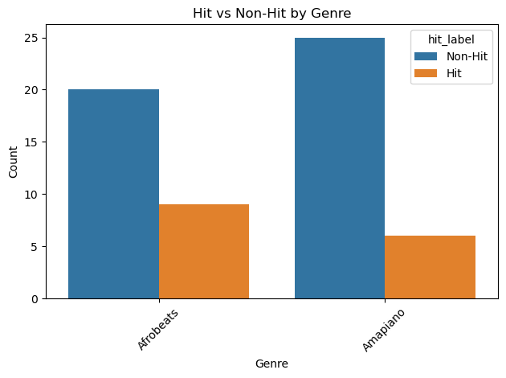

```python
import seaborn as sns
import matplotlib.pyplot as plt

# Clean the columns classify_hit needs
df['in_billboard_africa'] = df['in_billboard_africa'].fillna(0).astype(int)
if df['streams_per_day'].dtype == object:
    df['streams_per_day'] = df['streams_per_day'].replace(',', '', regex=True).astype(int)

def classify_hit(row):
    g = row['genre'].lower(); m = 0
    if g == 'afrobeats':
        if row['popularity'] >= 73: m += 1
        if row['viral_on_tiktok'] == 1: m += 1
        if row['streams_per_day'] >= 300000: m += 1
        if row['in_billboard_africa'] == 1: m += 1
        return 1 if m >= 3 else 0
    elif g == 'amapiano':
        if row['popularity'] >= 65: m += 1
        if row['viral_on_tiktok'] == 1: m += 1
        if row['streams_per_day'] >= 75000: m += 1
        return 1 if m >= 3 else 0
    return 0

df['is_hit'] = df.apply(classify_hit, axis=1)
df['hit_label'] = df['is_hit'].map({0: 'Non-Hit', 1: 'Hit'})



sns.countplot(data=df, x='genre', hue='hit_label')
plt.title("Hit vs Non-Hit by Genre")
plt.xlabel("Genre"); plt.ylabel("Count")
plt.xticks(rotation=45); plt.tight_layout(); plt.show()
#It appears that afrobeats songs are more likely to become hits than amapiano,
#which ultimately makes sense, the craze for amapiano is new, with celebrities like Tyla making it come to light
```

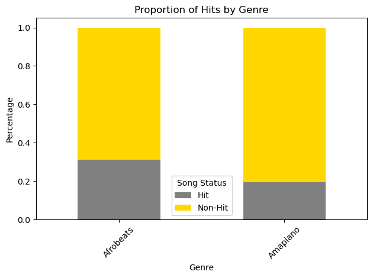

```python
genre_hit_rate = df.groupby('genre')['hit_label'].value_counts(normalize=True).unstack().fillna(0)
genre_hit_rate.plot(kind='bar', stacked=True, color=['gray', 'gold'])
plt.title('Proportion of Hits by Genre')
plt.ylabel('Percentage')
plt.xlabel('Genre')
plt.xticks(rotation=45)
plt.legend(title='Song Status')
plt.tight_layout()
plt.show()
```

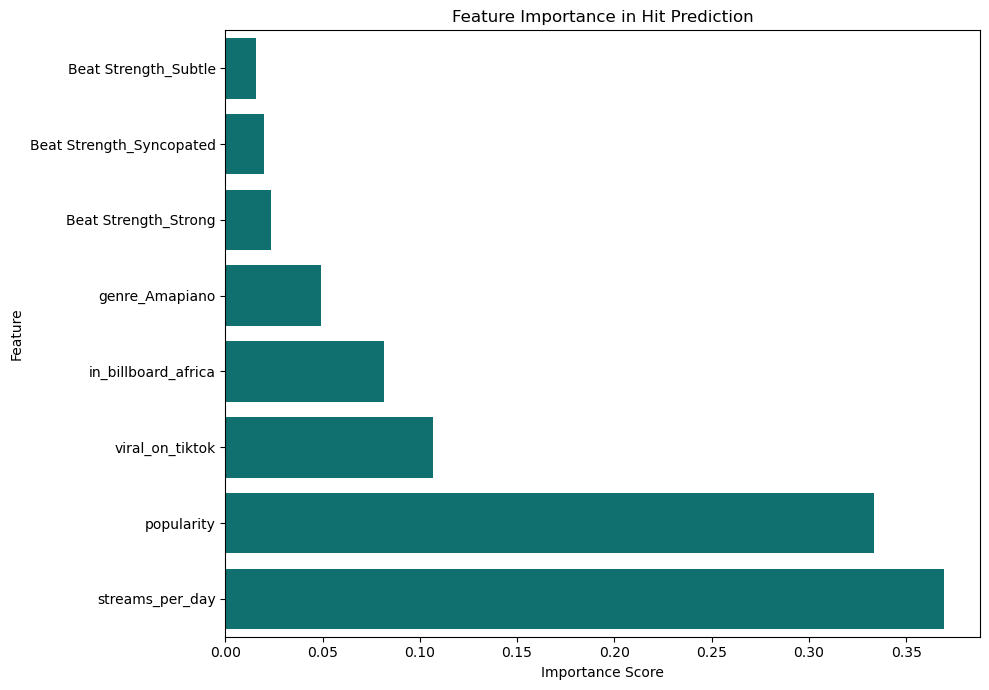

```
(array([[14,  1],
        [ 0,  3]]),
 {'0': {'precision': 1.0,
   'recall': 0.9333333333333333,
   'f1-score': 0.9655172413793104,
   'support': 15.0},
  '1': {'precision': 0.75,
   'recall': 1.0,
   'f1-score': 0.8571428571428571,
   'support': 3.0},
  'accuracy': 0.9444444444444444,
  'macro avg': {'precision': 0.875,
   'recall': 0.9666666666666667,
   'f1-score': 0.9113300492610837,
   'support': 18.0},
  'weighted avg': {'precision': 0.9583333333333334,
   'recall': 0.9444444444444444,
   'f1-score': 0.9474548440065682,
   'support': 18.0}})
```

```python
#Fill NaN values with 0 and convert to integer
df['in_billboard_africa'] = df['in_billboard_africa'].fillna(0).astype(int)

#Repeat the classification, modeling, and visualization steps as intended
def classify_hit(row):
    genre = row['genre'].lower()
    conditions_met = 0

    if genre == 'afrobeats':
        if row['popularity'] >= 73:
            conditions_met += 1
        if row['viral_on_tiktok'] == 1:
            conditions_met += 1
        if row['streams_per_day'] >= 300000:
            conditions_met += 1
        if row['in_billboard_africa'] == 1:
            conditions_met += 1
        return 1 if conditions_met >= 3 else 0

    elif genre == 'amapiano':
        if row['popularity'] >= 65:
            conditions_met += 1
        if row['viral_on_tiktok'] == 1:
            conditions_met += 1
        if row['streams_per_day'] >= 75000:
            conditions_met += 1
        return 1 if conditions_met >= 3 else 0

    return 0

df['is_hit'] = df.apply(classify_hit, axis=1)

#Create binary label and one-hot encode categorical variables
df_model = df.copy()
df_model['is_hit_binary'] = df_model['is_hit']

df_ml = pd.get_dummies(df_model[['popularity', 'streams_per_day', 'viral_on_tiktok',
                                 'in_billboard_africa', 'genre', 'Beat Strength', 'is_hit_binary']],
                       columns=['genre', 'Beat Strength'], drop_first=True)

#Train/test split and modeling
from sklearn.model_selection import train_test_split
from sklearn.ensemble import RandomForestClassifier
from sklearn.metrics import classification_report, confusion_matrix

X = df_ml.drop('is_hit_binary', axis=1)
y = df_ml['is_hit_binary']
X_train, X_test, y_train, y_test = train_test_split(X, y, test_size=0.3, random_state=42)

model = RandomForestClassifier(n_estimators=100, random_state=42)
model.fit(X_train, y_train)
y_pred = model.predict(X_test)

#Feature importance visualization
importances = pd.Series(model.feature_importances_, index=X.columns).sort_values(ascending=True)

import matplotlib.pyplot as plt
import seaborn as sns

plt.figure(figsize=(10,7))
sns.barplot(x=importances, y=importances.index, color='teal')
plt.title('Feature Importance in Hit Prediction')
plt.xlabel('Importance Score')
plt.ylabel('Feature')
plt.tight_layout()
plt.show()

#Feature Importance Bar Charts:Indicate that streams_per_day and popularity are the most influential predictors of a song’s
#success, followed by TikTok virality and Billboard presence.

#Final evaluation
conf_matrix = confusion_matrix(y_test, y_pred)
class_report = classification_report(y_test, y_pred, output_dict=True)

conf_matrix, class_report

#The classification report shows strong performance for hit-song prediction.
#The model achieved perfect recall for hits (1.00), meaning it identified all actual hit songs in the test set.
#Precision for hits was 0.75, indicating that some songs predicted as hits were not actually hits.
#Overall, the hit-class F1-score of 0.857 suggests the model captures useful hit-song patterns, though the small test size should
#be interpreted cautiously.
```

```python
#Ensure clean integer format in new data set ("playlist_and_all_audio_done.csv")
df['streams_per_day'] = df['streams_per_day'].replace(',', '', regex=True).astype(int)

#Apply classification function
df['is_hit'] = df.apply(classify_hit, axis=1)
```

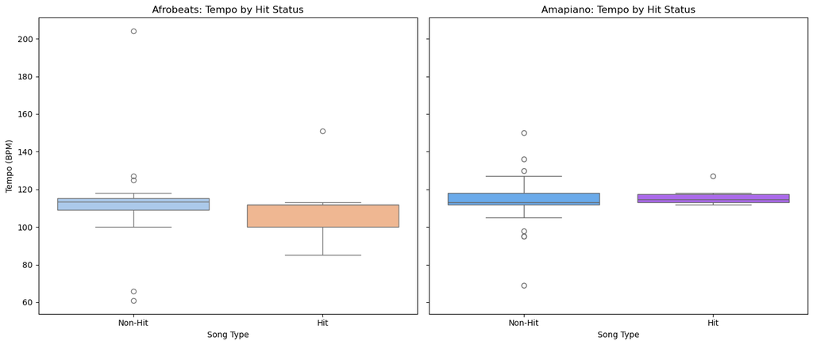

```python
import seaborn as sns
import matplotlib.pyplot as plt

#Map hit labels for readability
df['hit_label'] = df['is_hit'].map({0: 'Non-Hit', 1: 'Hit'})

#Set up the figure with 2 plots
fig, axes = plt.subplots(1, 2, figsize=(14, 6), sharey=True)

# --- Plot for Afrobeats ---
sns.boxplot(
    data=df[df['genre'] == 'Afrobeats'],
    x='hit_label',
    hue='hit_label',
    y='Tempo (BPM)',
    ax=axes[0],
    palette='pastel',
    legend=False

)
axes[0].set_title("Afrobeats: Tempo by Hit Status")
axes[0].set_xlabel("Song Type")
axes[0].set_ylabel("Tempo (BPM)")

# --- Plot for Amapiano ---
sns.boxplot(
    data=df[df['genre'] == 'Amapiano'],
    x='hit_label',
    y='Tempo (BPM)',
    hue='hit_label',
    ax=axes[1],
    palette='cool',
    legend=False

)
axes[1].set_title("Amapiano: Tempo by Hit Status")
axes[1].set_xlabel("Song Type")
axes[1].set_ylabel("")  # Shared y-axis

plt.tight_layout()
plt.show()

#Afrobeats: In this sample, Afrobeats hits lean toward slightly lower or mid-tempos. With only ~9 hit songs, though,
#this pattern is suggestive rather than conclusive.

#Amapiano: Tempo appears more consistent between hits and non-hits, with both centered tightly around a median — indicating
#that tempo may be less decisive in hit prediction for this genre.
```

```python
from sklearn.model_selection import train_test_split
from sklearn.linear_model import LogisticRegression
from sklearn.metrics import classification_report

# Prepare target variable
df['is_hit_binary'] = df['is_hit']

# Split data by genre
df_afro = df[df['genre'] == 'Afrobeats']
df_amap = df[df['genre'] == 'Amapiano']

# One-hot encode features separately by genre
X_afro = pd.get_dummies(
    df_afro[['popularity', 'streams_per_day', 'viral_on_tiktok',
             'in_billboard_africa', 'Beat Strength']],
    columns=['Beat Strength'],
    drop_first=True
)
y_afro = df_afro['is_hit']

X_amap = pd.get_dummies(
    df_amap[['popularity', 'streams_per_day', 'viral_on_tiktok',
             'in_billboard_africa', 'Beat Strength']],
    columns=['Beat Strength'],
    drop_first=True
)
y_amap = df_amap['is_hit']

# Stratified train-test split to preserve hit/non-hit balance
X_afro_train, X_afro_test, y_afro_train, y_afro_test = train_test_split(
    X_afro, y_afro, test_size=0.3, stratify=y_afro, random_state=42
)

X_amap_train, X_amap_test, y_amap_train, y_amap_test = train_test_split(
    X_amap, y_amap, test_size=0.3, stratify=y_amap, random_state=42
)

# Fit genre-specific logistic regression models
log_afro = LogisticRegression(max_iter=5000).fit(X_afro_train, y_afro_train)
log_amap = LogisticRegression(max_iter=5000).fit(X_amap_train, y_amap_train)

# Generate classification reports
report_afro = classification_report(
    y_afro_test,
    log_afro.predict(X_afro_test),
    output_dict=True,
    zero_division=0
)

report_amap = classification_report(
    y_amap_test,
    log_amap.predict(X_amap_test),
    output_dict=True,
    zero_division=0
)

report_afro, report_amap

# === Genre-Specific Logistic Regression Interpretation ===

#Stratified sampling was used to keep the hit/non-hit balance more consistent in each train-test split.

#Afrobeats Model:
#The model achieved perfect precision, recall, and F1-score for both hits and non-hits.
#It correctly classified all 9 test songs, including all 3 hits.
#Because the test set is small, the 100% accuracy should be interpreted cautiously.

#Amapiano Model:
#The model performed well on non-hits but failed to identify hits.
#For hit songs, precision, recall, and F1-score were all 0.00.
#Accuracy was 80%, but this is misleading because the model mostly predicted the majority class.

#Conclusion:
#Logistic regression worked well for Afrobeats in this split, but struggled with Amapiano hit prediction.
#Hit-class recall and F1-score are more important than accuracy because the goal is to identify hit songs.
```

```
({'0': {'precision': 1.0, 'recall': 1.0, 'f1-score': 1.0, 'support': 6.0},
  '1': {'precision': 1.0, 'recall': 1.0, 'f1-score': 1.0, 'support': 3.0},
  'accuracy': 1.0,
  'macro avg': {'precision': 1.0,
   'recall': 1.0,
   'f1-score': 1.0,
   'support': 9.0},
  'weighted avg': {'precision': 1.0,
   'recall': 1.0,
   'f1-score': 1.0,
   'support': 9.0}},
 {'0': {'precision': 0.8,
   'recall': 1.0,
   'f1-score': 0.8888888888888888,
   'support': 8.0},
  '1': {'precision': 0.0, 'recall': 0.0, 'f1-score': 0.0, 'support': 2.0},
  'accuracy': 0.8,
  'macro avg': {'precision': 0.4,
   'recall': 0.5,
   'f1-score': 0.4444444444444444,
   'support': 10.0},
  'weighted avg': {'precision': 0.64,
   'recall': 0.8,
   'f1-score': 0.711111111111111,
   'support': 10.0}})
```